# GLM Para dados discretos

Maiara Menezes

21 outubro, 2025

## 1 Introdução

Neste relatório vamos avaliar um banco de dados que explora a variação na quantidade de espécies (riqueza) da macrofauna bentônica identificadas em amostras coletadas 9 praias distintas.

As variáveis incluídas no banco de dados que foram coletadas em campo são:

1. Sample: Número da amostra
2. Richness: Riqueza de macrofauna bentônica (variável numérica)
3. Exposure: Índice de exposição (que varia entre 8, 10 e 11 - categórica)
4. NAP: altura da estação de amostragem em relação à maré (variável numérica)
5. Beach: Praia em que foi feito a amostragem (variável categórica)

Mais detalhadamente, exposure é um índice composto pela ação das ondas, comprimento da zona de arrebentação, declive, tamanho dos grãos e profundidade da camada anaeróbica.

Este banco de dados é explorado no livro do Zuur (2009): https://www.highstat.com/index.php?view=article&id=17&catid=18. (Nome original do banco de dados: RIKZ)

### 1.1 Objetivo

Vamos analisar este banco de dados buscando responder a seguinte pergunta:

**Existe uma relação entre riqueza de espécies, a altura da estação de amostragem (NAP) e o índice de exposição à maré?**

Em outras palavras, queremos compreender se as áreas mais expostas à ação do hidrodinamismo são áreas em que menos espécies ocorrem, diante os desafios de permanecer exposto ao ar, ao vento e a força das ondas. Em contraste, as áreas que permanecem submersas por mais tempo e que estão menos expostas a estas intempéries seriam aquelas que contarão com um maior número de espécies (maior riqueza).

Vamos iniciar importando os dados e fazendo uma breve análise exploratória.

```r
#~~~~~~~~~~~~~~~~~~~~~~~~~~~~~~~~
# 1. Importando o banco de dados
#~~~~~~~~~~~~~~~~~~~~~~~~~~~~~~~~
dados <- readRDS("../Dados/benthos_exposure.rds")
```

Vejamos brevemente algumas características gerais do banco de dados:

```r
#~~~~~~~~~~~~~~~~~~~~~~~~~~
# 2. Análise exploratória
#~~~~~~~~~~~~~~~~~~~~~~~~~~
str(dados)
```

```
## 'data.frame':    45 obs. of  5 variables:
##  $ Sample  : int  1 2 3 4 5 6 7 8 9 10 ...
##  $ Richness: int  11 10 13 11 10 8 9 8 19 17 ...
##  $ Exposure: int  10 10 10 10 10 8 8 8 8 8 ...
##  $ NAP     : num  0.045 -1.036 -1.336 0.616 -0.684 ...
##  $ Beach   : int  1 1 1 1 1 2 2 2 2 2 ...
```

Observe que exposure e beach são variáveis categóricas. Então, precisamos indica-las como fatores. Para isso vamos usar o pacote `dplyr`

```r
#~~~~~~~~~~~~~~~~~~~~~~~~~~~~~~~~
# 3. Ajustando o formato da variável resposta
#~~~~~~~~~~~~~~~~~~~~~~~~~~~~~~~~

library(dplyr)

cols <- c("Exposure", "Beach")
dados[, cols] <- lapply(dados[, cols], factor)
```

É fundamental explorar um pouco nossa variável de interesse para entender sua distribuição.

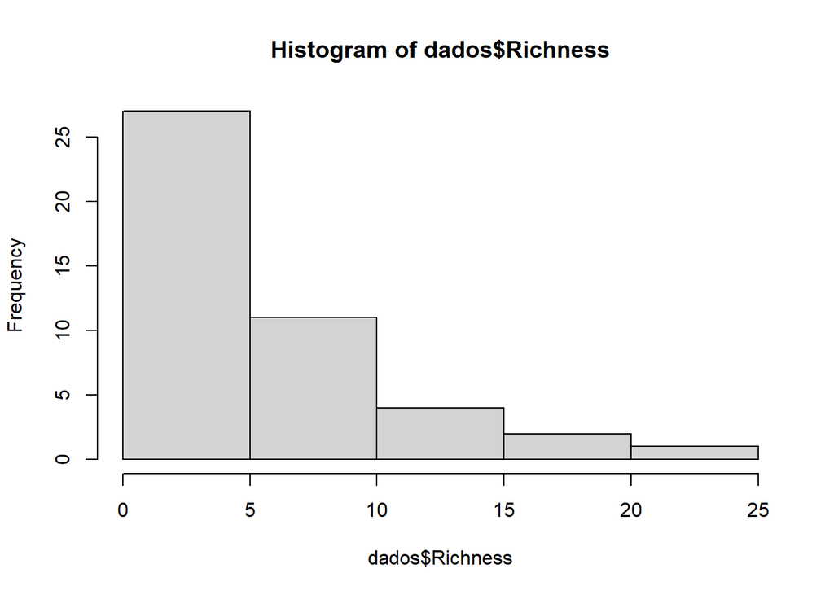

```r
#~~~~~~~~~~~~~~~~~~~~~~~~~~~~~~~~
# 4. Explorando a variável resposta
#~~~~~~~~~~~~~~~~~~~~~~~~~~~~~~~~

hist(dados$Richness)
```

```r
summary(dados$Richness)
```

```
##    Min. 1st Qu.  Median    Mean 3rd Qu.    Max.
##   0.000   3.000   4.000   5.689   8.000  22.000
```

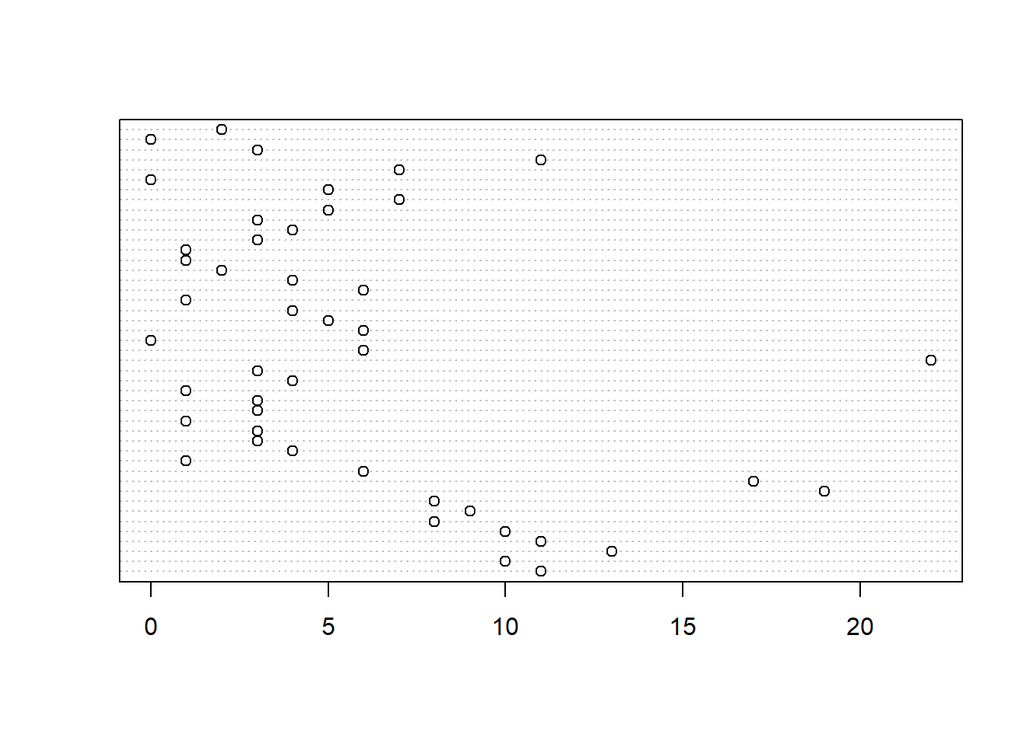

```r
dotchart(dados$Richness)
```

Como podemos ver, nossa variável preditora é discreta e tem uma distribuição assimétrica, típica de dados de contagem, com uma maior ocorrência de dados próximos ao zero e alguns dados pontuais >10. Para lidar com esse tipo de dado, temos que utilizar modelos lineares que tenham uma distribuição diferente da normal (gaussiana) e que considere esta particularidade de assimetria, como no caso da distribuição de poisson ou a binomial negativa.

Antes de seguir com a construção do modelo, podemos explorar a relação entre a nossa variável preditora (riqueza) e as nossas covariáveis ambientais (Exposure e NAP).

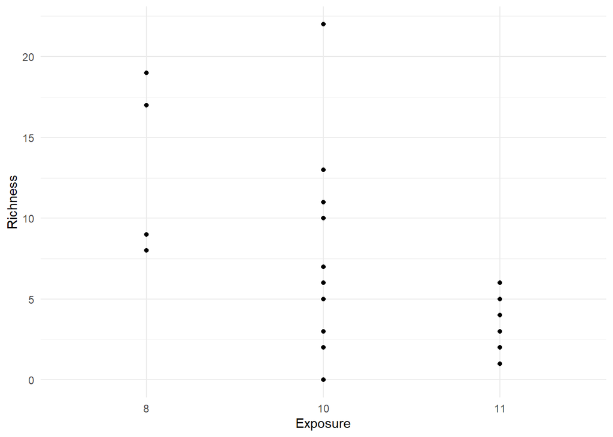

```r
#~~~~~~~~~~~~~~~~~~~~~~~~~~~~~~~~
# 5. Relação Riqueza vs. Exposição
#~~~~~~~~~~~~~~~~~~~~~~~~~~~~~~~~

library(ggplot2)
ggplot(dados, aes(x = Exposure, y = Richness)) +
  geom_point(fill = 'cyan4') +
  theme_minimal()
```

Podemos observar que possivelmente existe uma diferença na riqueza das espécies a depender do nível de exposição, sendo os pontos de amostragem com menor nível de exposição (8) aqueles que em que foram registradas mais espécies, e os com maior grau de exposição, os que obtiveram menos espécies registradas.

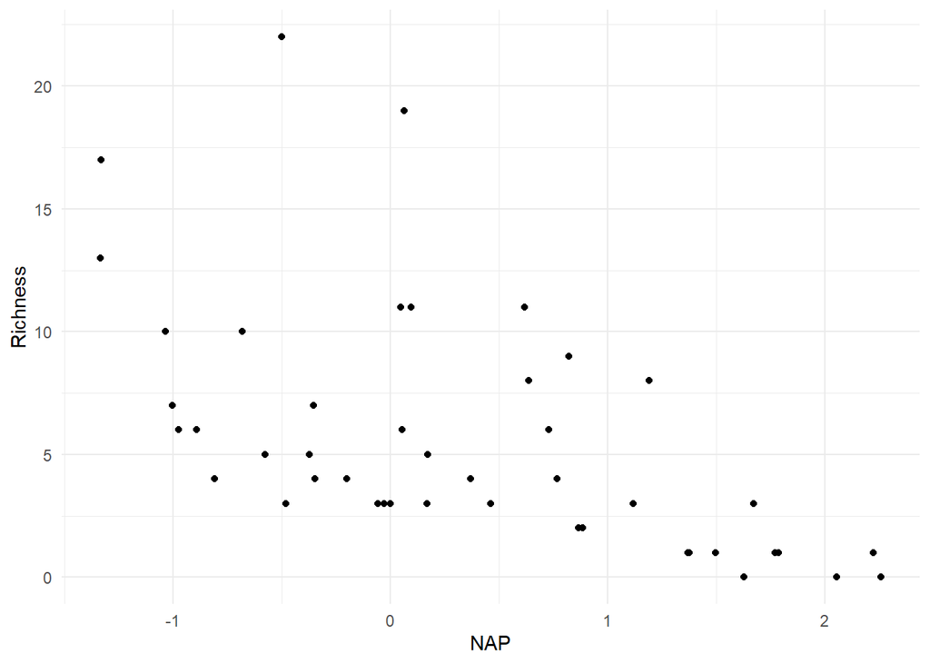

```r
#~~~~~~~~~~~~~~~~~~~~~~~~~~~~~~~~
# 5. Relação Riqueza vs. Altura da estação de coleta (NAP)
#~~~~~~~~~~~~~~~~~~~~~~~~~~~~~~~~

ggplot(dados, aes(x = NAP, y = Richness)) +
  geom_point(fill = 'cyan4') +
  theme_minimal()
```

Já em relação ao NAP, existe uma relação negativa entre a a riqueza e a altura da estação de amostragem, indicando que quanto maior a altura do ponto de amostragem, menor a quantidade de espécies.

Identificadas essas tendências podemos partir para o nosso teste de hipóteses.

## 2 Hipóteses

Com base na breve análise exploratória realizada anteriormente, podemos começar a formular algumas hipóteses:

- $H_1:$ A riqueza de espécies da macrofauna betônica diminui quanto mais altas as áreas intermarés e maior o índice de exposição as intempéries da ação das ondas, característica da zona de arrebentação.

## 3 Metodologia

Para testar esta hipótese, vamos estruturar um modelo que considere as duas covariáveis ambientais e que apresente uma distribuição assimétrica dos resíduos, própria para dados de contagem.

Lembrando que a distribuição de poisson é estruturada a partir de uma função logarítmica, para que a média dos valores de y ($(\lambda_i)$) assumam sempre valores positivos (>0), já que não existe contagem negativa para o número de espécies. Temos enquanto a seguinte relação:
$$\large y_i \sim Poisson(\lambda_i)$$
Onde $y_i$ é a riqueza da i*esma* amostra e $\lambda_i$ é a média do número de espécies (riqueza). Adicionalmente, como estamos trabalhando com um modelo aditivo generalizado, devemos assumir que:
$$\large log(\lambda_i) = \eta_i = \beta_0
+\sum_{j=1}^{J} \beta_j x_{ij}$$

Onde $log(\lambda_i)$ é o componente randômico, que sempre deverá assumir um valor positivo; $\beta_0$ o intercepto, $j$ número de covariáveis, $\beta_j$ os coeficientes que quantificam o efeito das covariáveis $x_j$; e $\eta_i$ a função de ligação entre esses dois componentes.

Podemos escrever o modelo completo, conforme

$$log(\lambda_i) = \beta_0 + \beta_1
Exposição_{i} + \beta_2 NAP_{i}$$

Adicionalmente, essa distribuição assume que a média e a variância são equivalentes.

Este modelo é suficiente para responder aos dois objetivos específicos. No entanto, testaremos diversos modelos para achar o modelo que melhor se ajuste aos dados. Para tanto, usaremos o método “forward-stepwise”, em que partimos do modelo nulo e inserimos uma covariável por vez.

Os modelos serão comparados pelos valores de AIC e, quando necessário, contrastados (testados) via o *teste de razão de verossimilhança*. Além disso, o ajuste dos modelos será analisado via análises gráficas dos resíduos.

## 4 Análise e Resultados

Iniciaremos as análises montando os modelos, partindo do modelo mais simples (modelo nulo) para o modelo mais complexo (contém todas as covariáveis).

```r
#~~~~~~~~~~~~~~~~~~~~~~~~~~~~~~~~
# 6. Testando modelos
#~~~~~~~~~~~~~~~~~~~~~~~~~~~~~~~~

## Modelo Nulo
mod0 <- glm(Richness ~ 1,
            family = poisson (link = "log"),
            data = dados)

## Modelo 1
mod1 <- glm(Richness ~ NAP,
            family = poisson (link = "log"),
            data = dados)

## Modelo 2
mod2 <- glm(Richness ~ Exposure,
            family = poisson (link = "log"),
            data = dados)

## Modelo 3
mod3 <- glm(Richness ~ NAP + Exposure,
            family = poisson (link = "log"),
            data = dados)
```

Agora que temos alguns modelos, podemos compará-los via valores de AIC

```r
#~~~~~~~~~~~~~~~~~~~~~~~~~~~~~~~~
# 7. Comparando os modelos
#~~~~~~~~~~~~~~~~~~~~~~~~~~~~~~~~

## Calcular os valores de AIC ##
aic <- AIC(mod0, mod1, mod2, mod3)


## Ordenar dos menores aos maiores valores ##
aic %>% arrange(-AIC)
```

```
##      df      AIC
## mod0  1 323.7514
## mod2  3 265.2859
## mod1  2 259.1807
## mod3  4 208.3707
```

Como podemos observar, o modelo 3 foi aquele com o menor valor de AIC. Podemos averiguar de ele difere significativamente o segundo melhor modelo (mod 1) antes de avalia-lo graficamente.

```r
#~~~~~~~~~~~~~~~~~~~~~~~~~~~~~~~~
# 8. Teste de razão de verossimilhança
#~~~~~~~~~~~~~~~~~~~~~~~~~~~~~~~~

#lmtest::lrtest(mod3, mod2) # mesma coisa
anova(mod3, mod1, test = "Chisq")
```

```
## Analysis of Deviance Table
##
## Model 1: Richness ~ NAP + Exposure
## Model 2: Richness ~ NAP
##   Resid. Df Resid. Dev Df Deviance  Pr(>Chi)
## 1        41     58.372
## 2        43    113.182 -2   -54.81 1.254e-12 ***
## ---
## Signif. codes:  0 '***' 0.001 '**' 0.01 '*' 0.05 '.' 0.1 ' ' 1
```

Constatada a diferença entre os modelos podemos partir para análise gráfica dos resíduos para validá-lo.

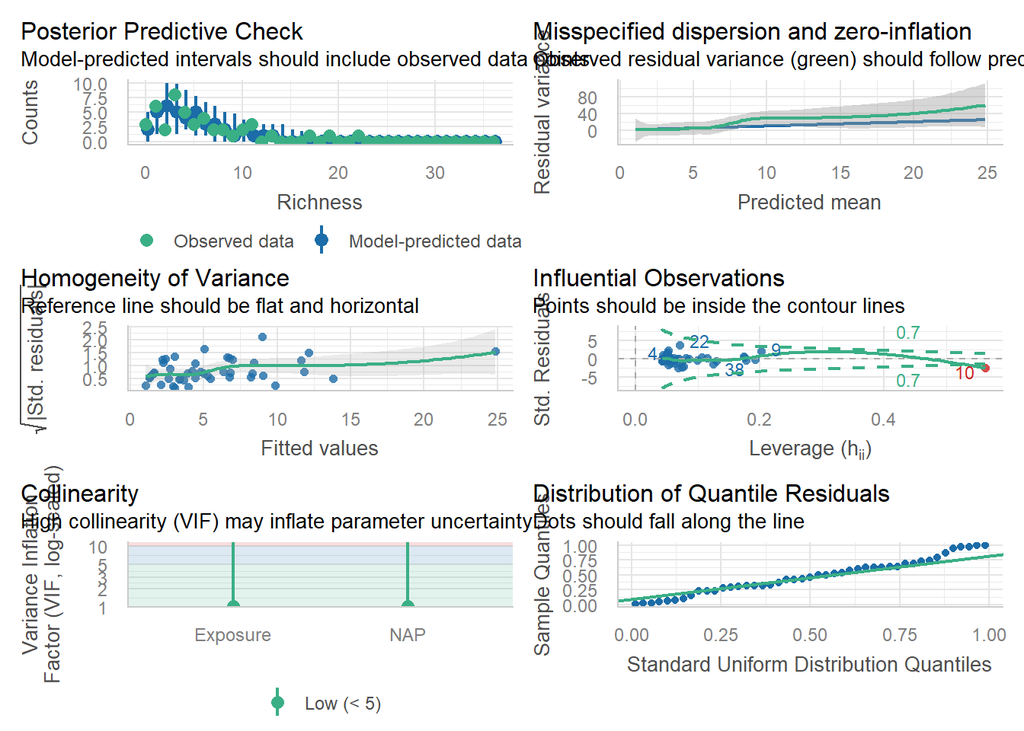

```r
#~~~~~~~~~~~~~~~~~~~~~~~~~~~~~~~~
# 9.Validação do modelo
#~~~~~~~~~~~~~~~~~~~~~~~~~~~~~~~~

library(performance)
check_model(mod3)
```

```r
check_overdispersion(mod3)
```

```
## # Overdispersion test
##
##        dispersion ratio =  1.410
##   Pearson's Chi-Squared = 57.821
##                 p-value =  0.042
```

Observando os gráficos podemos constatar que apesar de os valores preditos estarem bem próximos dos valores estimados (plot 1) a variância residual não está como esperado (plot 3 e 6). Além disso, é possível identificar que algumas poucas observações influenciam a distribuição dos dados (plot 4). Além disso, o teste que verifica a sobredispersão dos dados foi significativo, o que demosntra outra fragilidade do modelo.

Desta forma, como o nosso melhor modelo não apresenta um ajuste ideal, podemos seguir explorando outros tipos de distribuição que possam nos ajudar a lidar com essas limitações. Uma possibilidade para o tipo de dado que estamos trabalhando é a binomial negativa.

```r
#~~~~~~~~~~~~~~~~~~~~~~~~~~~~~~~~
# 10.Testando o modelo com distribuição binomial negativa
#~~~~~~~~~~~~~~~~~~~~~~~~~~~~~~~~

library(MASS)
mod4<- glm.nb(Richness ~ NAP + Exposure,
            data = dados)

aic <- AIC(mod0, mod1, mod2, mod3, mod4)
aic %>% arrange(-AIC)
```

```
##      df      AIC
## mod0  1 323.7514
## mod2  3 265.2859
## mod1  2 259.1807
## mod3  4 208.3707
## mod4  5 206.0406
```

```r
anova(mod3, mod4, test = "Chisq")
```

```
## Analysis of Deviance Table
##
## Model 1: Richness ~ NAP + Exposure
## Model 2: Richness ~ NAP + Exposure
##   Resid. Df Resid. Dev Df Deviance Pr(>Chi)
## 1        41     58.372
## 2        41     40.753  0   17.619
```

Quando comparado aos modelos com a distribuição de Poisson, o modelo da binomial negativa apresentou de fato um AIC menor. Todavia, não existe diferença significativa entre os AICs do modelo cheio com distribuição de poisson e da binomial negativa. Neste caso, podemos partir para análise gráfica dos resíduos para tomar a decisão de qual modelo será considerado para intrepetar os resultados.

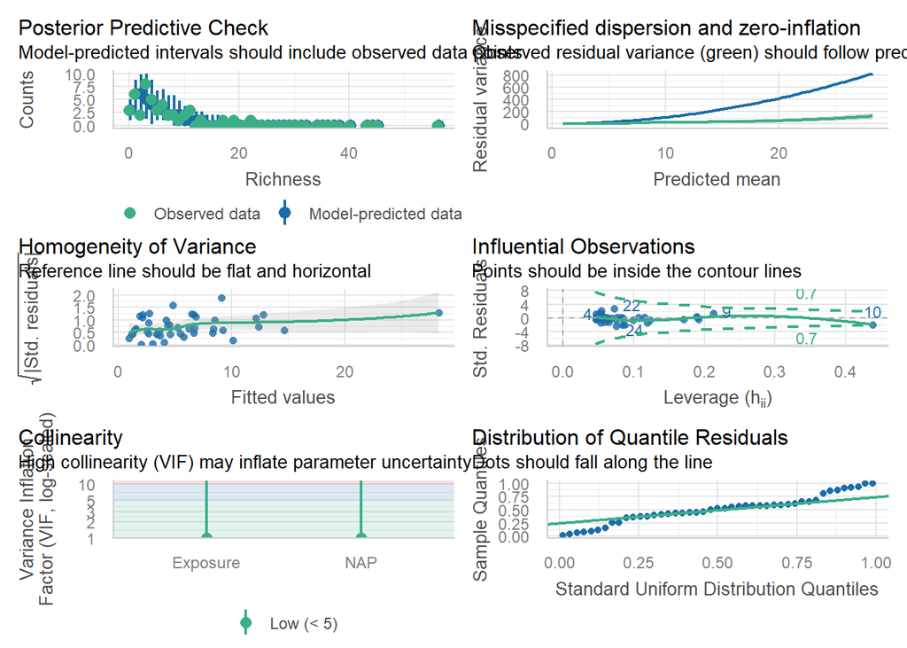

```r
#~~~~~~~~~~~~~~~~~~~~~~~~~~~~~~~~
# 11.Validação do modelo com distribuição binomial negativa
#~~~~~~~~~~~~~~~~~~~~~~~~~~~~~~~~

check_model(mod4)
```

```r
check_overdispersion(mod4)
```

```
## # Overdispersion test
##
##  dispersion ratio = 1.203
##           p-value = 0.416
```

Verificamos com essa análise gráfica que o modelo com distribuição binomial negativa apesar de contornar o problema da sobredispersão dos dados, acarretou num leve prejuízo quanto a normalidade dos resíduos. Considerando que não houve diferença significativa quanto ao critério de aic entre estes dois modelos, podemos eleger, pelo critério da parcimonia, o modelo mais simples apara analisar os resultados.

```r
#~~~~~~~~~~~~~~~~~~~~~~~~~~~~~~~~
# 12. Resultados do modelo com distribuição de poisson
#~~~~~~~~~~~~~~~~~~~~~~~~~~~~~~~~

summary(mod3)
```

```
##
## Call:
## glm(formula = Richness ~ NAP + Exposure, family = poisson(link = "log"),
##     data = dados)
##
## Coefficients:
##             Estimate Std. Error z value Pr(>|z|)
## (Intercept)   2.5269     0.1287  19.628  < 2e-16 ***
## NAP          -0.5137     0.0693  -7.414 1.23e-13 ***
## Exposure10   -0.5898     0.1543  -3.823 0.000132 ***
## Exposure11   -1.3312     0.1822  -7.305 2.78e-13 ***
## ---
## Signif. codes:  0 '***' 0.001 '**' 0.01 '*' 0.05 '.' 0.1 ' ' 1
##
## (Dispersion parameter for poisson family taken to be 1)
##
##     Null deviance: 179.753  on 44  degrees of freedom
## Residual deviance:  58.372  on 41  degrees of freedom
## AIC: 208.37
##
## Number of Fisher Scoring iterations: 5
```